# Data science per psicologi - demo 11.01

Corrado Caudek

2022-03-22

```r
suppressPackageStartupMessages({
  library("tidyverse")
  library("prob")
  library("distrEx")
})

set.seed(84735)

knitr::opts_chunk$set(
  collapse = TRUE,
  tidy = 'styler',
  fig.width = 6,
  fig.asp = 0.618 # 1 / phi
)
```

# Esercizi sul valore atteso e sulla varianza

## Esercizio 1

Lanciamo 3 monete. Sia $Y$ il numero di volte in cui si ossserva Testa. Si trovi il valore atteso di $Y$, la sua varianza e la sua deviazione standard.

Usando le funzioni di `prob` generiamo lo spazio campione di questo esperimento casuale:

```r
S <- tosscoin(3, makespace = TRUE)
S
```

```
##   toss1 toss2 toss3 probs
## 1     H     H     H 0.125
## 2     T     H     H 0.125
## 3     H     T     H 0.125
## 4     T     T     H 0.125
## 5     H     H     T 0.125
## 6     T     H     T 0.125
## 7     H     T     T 0.125
## 8     T     T     T 0.125
```

Su questo spazio campione definisco la variabile casuale $Y$. Per trovare $Y$, prima assegno il valore 1 ad `H` e il valore 0 a `T`. Per fare questo, operativamente, semplicemente trasformo `H` in 1 e `T` in 0:

```r
S <- S %>%
  transmute(
    toss1 = ifelse(toss1 == "H", 1, 0),
    toss2 = ifelse(toss2 == "H", 1, 0),
    toss3 = ifelse(toss3 == "H", 1, 0),
    probs = probs
  )
S
```

```
##   toss1 toss2 toss3 probs
## 1     1     1     1 0.125
## 2     0     1     1 0.125
## 3     1     0     1 0.125
## 4     0     0     1 0.125
## 5     1     1     0 0.125
## 6     0     1     0 0.125
## 7     1     0     0 0.125
## 8     0     0     0 0.125
```

Adesso posso creare la variabile casuale $Y$ facendo la somma dei valori delle tre colonne `toss1`, `toss2`, `toss3`. A tale fine uso la funzione `addrv()`. Dal file di aiuto possiamo infatti leggere: *Adds a column to a data frame probability space containing the values of a random variable computed from the existing columns of the space.* Come argomento specifichiamo `sum`, dato che vogliamo combinare le tre colonne del DataFrame con una somma, e `name = "Y"`.

```r
S <- addrv(S, sum, name = "Y")
S
```

```
##   toss1 toss2 toss3 Y probs
## 1     1     1     1 3 0.125
## 2     0     1     1 2 0.125
## 3     1     0     1 2 0.125
## 4     0     0     1 1 0.125
## 5     1     1     0 2 0.125
## 6     0     1     0 1 0.125
## 7     1     0     0 1 0.125
## 8     0     0     0 0 0.125
```

Quindi, la colonna `Y` nel DataFrame `S` riporta i valori della variabile casuale che abbiamo definito, *in corrispondenza di ciascun evento elementare dello spazio campione*.

```r
p_mar <- marginal(S, vars = c("Y"))
p_mar
```

```
##   Y probs
## 1 0 0.125
## 2 1 0.375
## 3 2 0.375
## 4 3 0.125
```

Per semplicità, estraggo da `p_mar` i valori della variabile casuale e le rispettive probabilità; salvo questi valori in due vettori:

```r
y <- p_mar$Y
p <- p_mar$probs
```

Calcolo il valore atteso

$$\mathbb{E}(Y) = \sum_{y \in Y} y P(Y = y)$$

```r
mu <- sum(y * p)
mu
```

```
## [1] 1.5
```

La varianza si può calcolare in due modi:

$$\mathbb{V}(Y) = \mathbb{E}\big[(y - \mathbb{E}(Y))^2\big]$$
cioè

$$\mathbb{V}(Y) = \sum_{y \in Y}(y - \mathbb{E}(Y))^2 P(y = Y)$$
In $\mathsf{R}$:

```r
sigma2 <- sum((y - mu)^2 * p)
sigma2
```

```
## [1] 0.75
```

Verifico il risultato con la formula alternativa della varianza:

$$\mathbb{V}(Y) = \mathbb{E}(Y^2) - \big[\mathbb{E}(Y)\big]^2$$

```r
sum(y^2 * p) - (sum(y * p))^2
```

```
## [1] 0.75
```

La deviazione standard è

```r
sigma <- sqrt(sigma2)
sigma
```

```
## [1] 0.8660254
```

La distribuzione cumulativa di probabilità si ottiene nel modo seguente:

```r
F <- cumsum(p)
tibble(y, F)
```

```
## # A tibble: 4 × 2
##       y     F
##   <dbl> <dbl>
## 1     0 0.125
## 2     1 0.5
## 3     2 0.875
## 4     3 1
```

## Pacchetto `distrEx`

Uso le funzioni di `distrEx` per eseguire in maniera più semplice gli stessi calcoli descritti sopra. Creo un oggetto di classe `DiscreteDistribution`:

```r
Y <- DiscreteDistribution(
  supp = 0:3,
  prob = c(1, 3, 3, 1) / 8
)
class(Y)
```

```
## [1] "DiscreteDistribution"
## attr(,"package")
## [1] "distr"
```

Tale oggetto può essere passato come argomento alla funzione `plot()`:

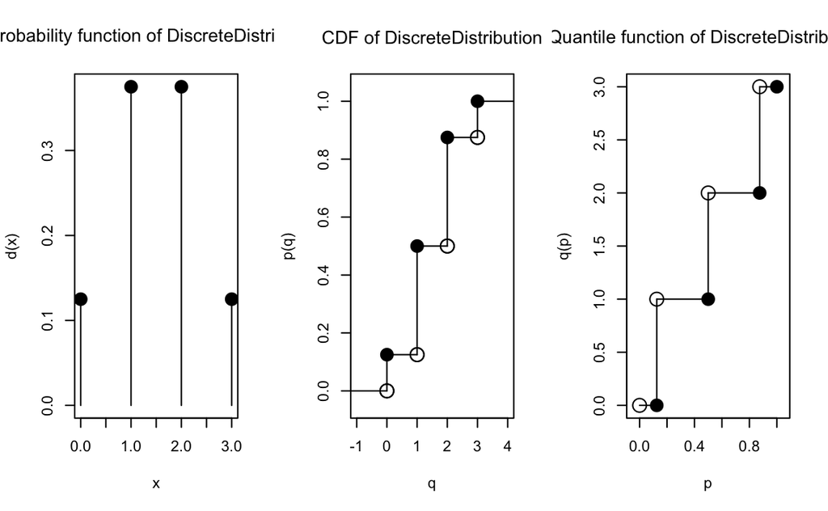

```r
plot(Y)
```

Calcolo il valore atteso:

```r
distrEx::E(Y)
```

```
## [1] 1.5
```

Calcolo la varianza:

```r
distrEx::var(Y)
```

```
## [1] 0.75
```

Calcolo la deviazione standard:

```r
distrEx::sd(Y)
```

```
## [1] 0.8660254
```